# Project : Marketing Campaign and Profit Prospect Analysis using Deep Learning

# PART 1 -- DATA PROCESSING AND EXPLORATORY DATA ANALYSIS

# Importing the Modules

```python
import pandas as pd
import numpy as np
import matplotlib.pyplot as plt
import seaborn as sns
import warnings
warnings.filterwarnings('ignore')
```

# Loading the dataset

```python
df = pd.read_csv('Project_dataset.csv')
df.head(3)
```

|  | Unnamed: 0 | ID | DemAffl | DemAge | DemClusterGroup | DemGender | LoyalClass | LoyalSpend | LoyalTime | Region | TargetBuy |
| --- | --- | --- | --- | --- | --- | --- | --- | --- | --- | --- | --- |
| 0 | 0 | 17147654 | 5.0 | NaN | NaN | NaN | Tin | 0.01 | 5.0 | London | 0 |
| 1 | 1 | 8415498 | 15.0 | NaN | NaN | M | Gold | 8000.00 | 5.0 | London | 1 |
| 2 | 2 | 12107603 | NaN | NaN | NaN | M | Tin | 0.01 | NaN | Birmingham | 0 |

```python
# The dataset has 22,223 rows and 10 columns (Excluding the Unnamed column)
df.shape
```

```
(22223, 11)
```

# Data Processing

```python
# Dropping the non required feature.
df.drop('Unnamed: 0',axis=1,inplace=True)
```

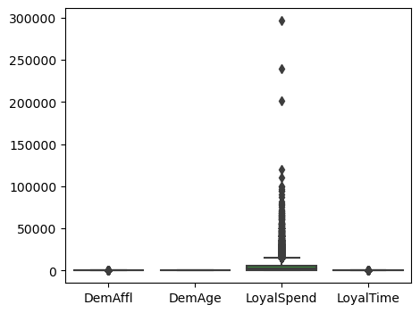

```python
# Identifying the outlier using Boxplot

plt.figure(figsize=(5,4))
sns.boxplot(df[['DemAffl','DemAge','LoyalSpend','LoyalTime']])
plt.show()
```

### Observation -- Outliers are present in the dataset

```python
# Treating the outliers using the Capping method.

for i in df.columns[1:-1]:
    if df[i].dtype!='object':
        q1 = df[i].quantile(0.25)
        q3 = df[i].quantile(0.75)
        IQR=q3-q1

        lower = q1-1.5*IQR
        upper = q3+1.5*IQR
        df[i]=np.where(df[i]>upper,upper,np.where(df[i]<lower,lower,df[i]))
```

### Here, Capping method is used instead of removing the outliers so that the data is not lost. In capping method, outlier values are replaced either with the upper limit or with the lower limit of the Interquartile range(IQR).

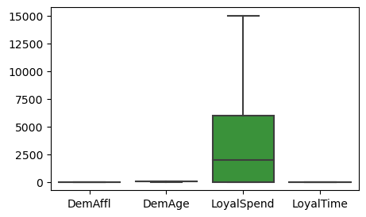

```python
# Re-checking the outliers after capping

plt.figure(figsize=(5,3))
sns.boxplot(df[['DemAffl','DemAge','LoyalSpend','LoyalTime']])
plt.show()
```

```python
# Identifying the null values in the dataset
df.isnull().sum()
```

```
ID                    0
DemAffl            1085
DemAge             1508
DemClusterGroup     674
DemGender          2512
LoyalClass            0
LoyalSpend            0
LoyalTime           281
Region                0
TargetBuy             0
dtype: int64
```

```python
# Filling the null values

for i in df.columns:
    if df[i].dtype=='object':
        df[i].fillna(df[i].mode()[0],inplace=True)  # Filling the Null values in categorical columns using mode value.
    elif df[i].dtype!='object':
        df[i].fillna(df[i].mean(),inplace=True)    # Filling the null values in numeric columns using mean value.
    else:
        print('Error')
```

# Exploratory Data Analysis (EDA)

```
Silver      8572
Tin         6487
Gold        6324
Platinum     840
Name: LoyalClass, dtype: int64
```

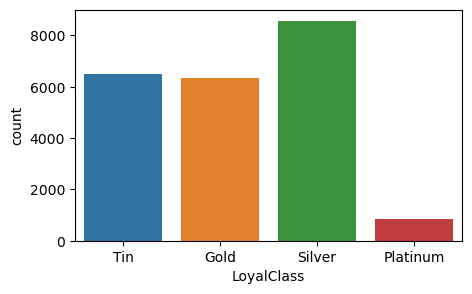

```python
# Countplot of LoyalClass

plt.figure(figsize=(5,3))
sns.countplot(x='LoyalClass',data=df)
print(df['LoyalClass'].value_counts())
plt.show()
```

## Observation

- Silver class has the highest number of customers, that is 38.57 % of total customers , whereas Platinum class has the lowest (3.77 %).
- Tin and Gold class collectively represents 57.64 % of the total customers and they do not have much difference in customer participation.

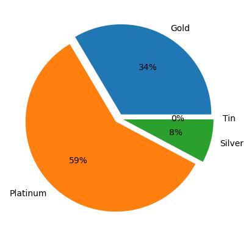

```python
# Relationship between average amount spent by each class using a pie chart

explode = (0.05,0.05,0.05,0.05)
df.groupby('LoyalClass').mean().plot(kind='pie',y='LoyalSpend',autopct='%1.0f%%',explode=explode,legend=False)
plt.axis('off')
plt.show()
```

## Observation

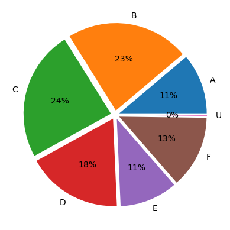

```python
# Analysis of total amount spent based on each cluster using pie chart

explode = (0.05,0.05,0.05,0.05,0.05,0.05,0.05)
df.groupby('DemClusterGroup').sum().plot(kind='pie',y='LoyalSpend',autopct='%1.0f%%',explode=explode,legend=False)
plt.axis('off')
plt.show()
```

## Observation

- Cluster B and cluster C have nearly equal contribution in the total amount spent and collectively they contribute 47 % of total amount spent.
- Similary, cluster A and E have equal contribution in total amount spent and together they contribute 22 % of total amount spent.
- Cluster D has the third highest share in total amount spent, whereas cluster U has the lowest.

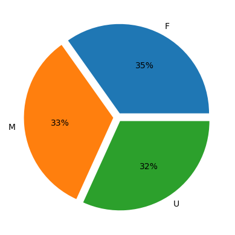

```python
# Analysis of average affluence grade based on gender

explode = (0.05,0.05,0.05)
df.groupby('DemGender').mean().plot(kind='pie',y='DemAffl',autopct='%1.0f%%',explode=explode,legend=False)
plt.axis('off')
plt.show()
```

## Observation

- Females have the highest averegae affluent grade, and they are more likely to buy the product.
- Male and the other category have nearly equal affluent grade.
- There is no sharp difference of affluence between Male, female and the other category.

```
DemClusterGroup  TargetBuy
A                0            1201
                 1             649
B                0            2671
                 1            1473
C                0            3455
                 1            1785
D                0            2834
                 1            1544
E                0            1645
                 1             963
F                0            2524
                 1            1425
U                0              34
                 1              20
dtype: int64
```

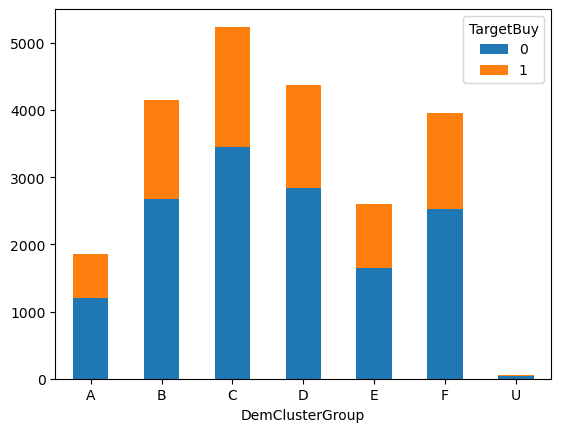

```python
# Relationship between Clusters and target buyers using stacked bar chart

df.groupby(by=['DemClusterGroup','TargetBuy']).size().unstack().plot(kind='bar',stacked=True)
print(df.groupby(by=['DemClusterGroup','TargetBuy']).size())
plt.xticks(rotation=0)
plt.show()
```

## Observation

```
LoyalClass  TargetBuy
Gold        0            4154
            1            2170
Platinum    0             537
            1             303
Silver      0            5558
            1            3014
Tin         0            4115
            1            2372
dtype: int64
```

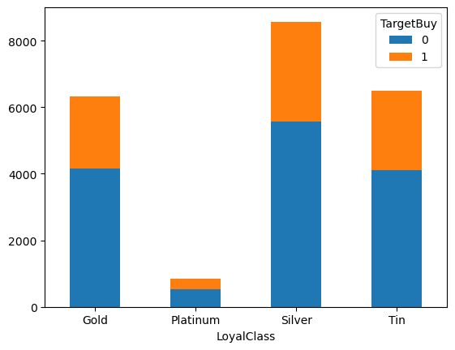

```python
# Relationship between Loyal class and target buy using stacked bar chart

df.groupby(by=['LoyalClass','TargetBuy']).size().unstack().plot(kind='bar',stacked=True)
print(df.groupby(by=['LoyalClass','TargetBuy']).size())
plt.xticks(rotation=0)
plt.show()
```

## Observation

- Silver class has the highest number of buyers (3014), followed by Tin class (2372), and collectively they represents contributes 68.53 % of the total buyers.
- Silver class also has the highest number of non buyers (5558), followed by the Gold class (4154).
- Platinum class has the lowest number of buyers (303) as well as non buyers (537).

```
Region      TargetBuy
Birmingham  0            1031
            1             618
Bolton      0             528
            1             308
Bristol     0            1593
            1             852
Cardiff     0            1391
            1             705
Leicester   0             435
            1             256
London      0            4296
            1            2358
Midlands    0            1992
            1            1131
Nottingham  0             520
            1             265
Scotland    0             202
            1             127
Trafford    0             136
            1              67
Ulster      0             188
            1              78
Wales       0            1095
            1             608
Yorkshire   0             957
            1             486
dtype: int64
```

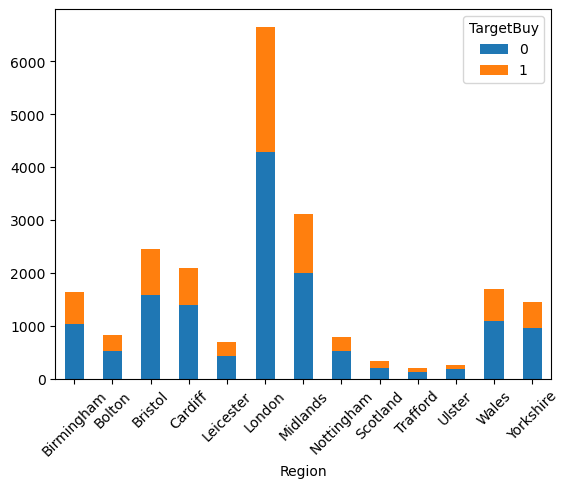

```python
# Relationship between Region and targetbuy using stacked bar chart

df.groupby(by=['Region','TargetBuy']).size().unstack().plot(kind='bar',stacked=True)
print(df.groupby(by=['Region','TargetBuy']).size())
plt.xticks(rotation=45)
plt.show()
```

## Observation

- London has the highest number of buyers (2358), followed by Midlands (1131) and then Bristol (852).
- Lowest number of buyers are from Trafford (67), followed by Ulster (78) and then Scotland (127).

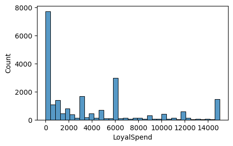

```python
# Distribution of Loyalty spent amount using Histogram

plt.figure(figsize=(5,3))
sns.histplot(df['LoyalSpend'])
plt.show()
```

## Observation

- The loyalty spent amount is skewed toward right.
- Majority of the spent amount is in the range of 0 to 6000.

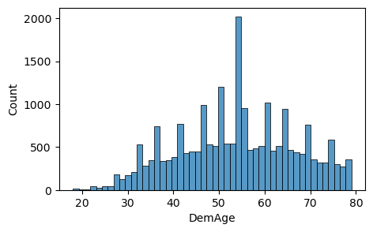

```python
# Distribution of Age using Histogram

plt.figure(figsize=(5,3))
sns.histplot(df['DemAge'])
plt.show()
```

## Observation

- The age distribution of the customers is fairly Normal as compared to the loyalty amount spent.
- Majority of age values lie in the range of 30 to 80.

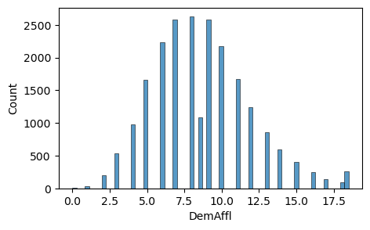

```python
# Distribution of Demographic Affluence using Histogram

plt.figure(figsize=(5,3))
sns.histplot(df['DemAffl'])
plt.show()
```

## Observations

- The demographic affluence values are normally distributed and majority of the values are in the range of 2.5 to to 15.

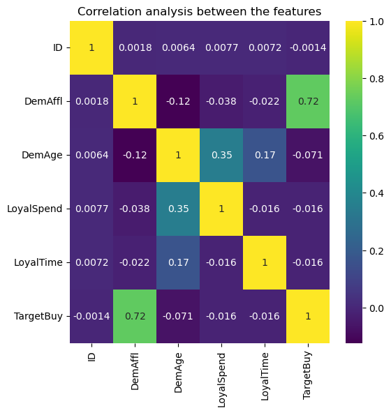

```python
# Analysis of correlation between numeric features using heatmap

plt.figure(figsize=(6,6))
sns.heatmap(df.corr(numeric_only=True),annot=True,cmap='viridis')
plt.title('Correlation analysis between the features')
plt.yticks(rotation=0)
plt.show()
```

## Observation

- Demographic affluence and TargetBuy have a strong positive correlation with each other (0.72), that means a customer with higher demographic affluent value is more likely to buy the product as compared to the customers with lower demographic affluent value.
- All the other variables have a weak correlation with the Target Buy output variable, that means, their impact in determining the output variable is low.

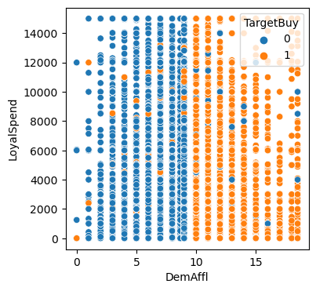

```python
# Scatterplot of Demographic affluence and amount spent with TargetBuy

plt.figure(figsize=(4,4))
sns.scatterplot(x = 'DemAffl', y = 'LoyalSpend',hue = 'TargetBuy', data = df)
plt.show()
```

## Observation

- Customers having demographic affluent value higher than 10 are more likely to buy the product.

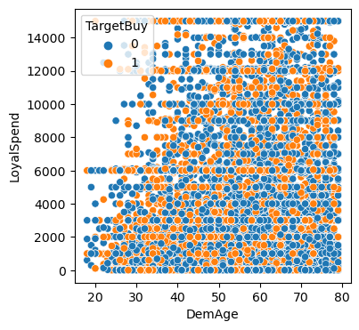

```python
# Scatterplot of Age and amount spent with TargetBuy

plt.figure(figsize=(4,4))
sns.scatterplot(x = 'DemAge', y = 'LoyalSpend',hue = 'TargetBuy', data = df)
plt.show()
```

# Saving the cleaned dataset for model building

```python
df.to_csv('After_EDA.csv')
```

# NOTE : The Deep Learning model building part of the project is performed in 'Marketing Campaign Strategy (Model Building)' file.